# Chemicals in Cosmetics

Sanchita Rathi

2022-19-12

# Introduction

COSMETICS A “cosmetic” is any substance used to clean, improve or change the complexion, skin, hair or, nails Cosmetics include beauty preparations (make-up, perfume, skin cream, nail polish).

CHEMICALS Artificially made substance that is used in or produced by a reaction involving changes to atoms or molecules which manipulates the formation when added in another substance.

# Introduction

CORRELATION (Chemicals in Cosmetics)

- Added Colors
- Appealing fragrance
- Artificial ingredients

# Objectives

To identify the relationship between the Chemicals and Cosmetics based on:

- Chemical Range
- Product categories and Sub categories
- Brand or Company names

# Data Source

- The data set consists of 100 samples
- Data set taken from kaggle.com

# Project Description

- Descriptive Analysis: Treemaps, Columncharts
- Extracted Analysis (Implications) : Pie Charts, Density Chart, BarChart

# Division of Cosmetic Categories

- Tree Map of Primary Category by Price
- Skin Care Products are the most Pricy
- Hair Coloring Product cost the lowest among other Products

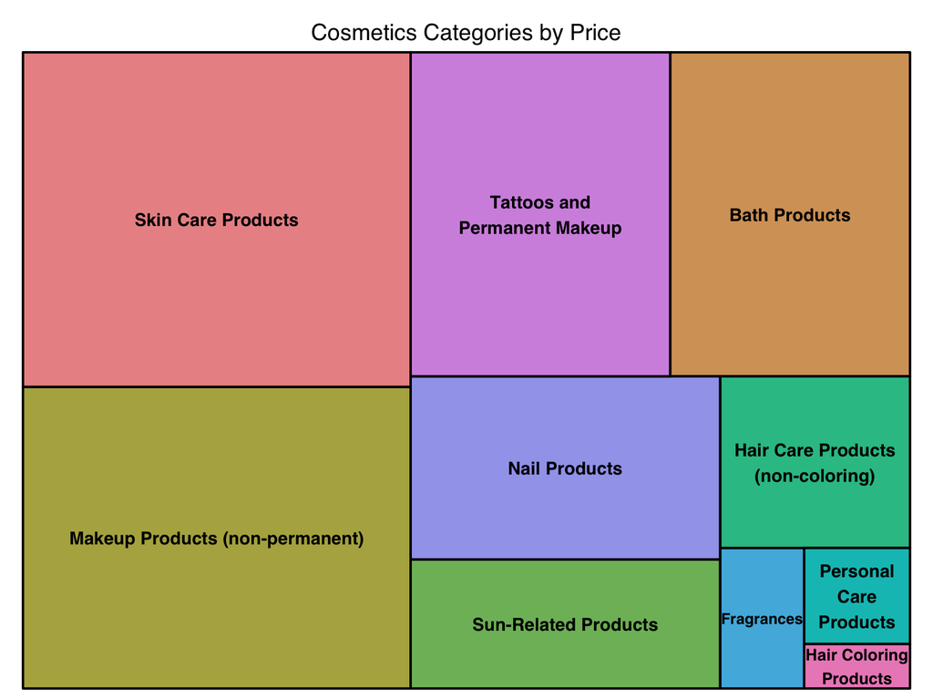

# Division of Subcategories

- Tree Map of Primary Category with their Sub-Category
- Under Skin care products, Skin moisturizers costs the most followed by Make up products

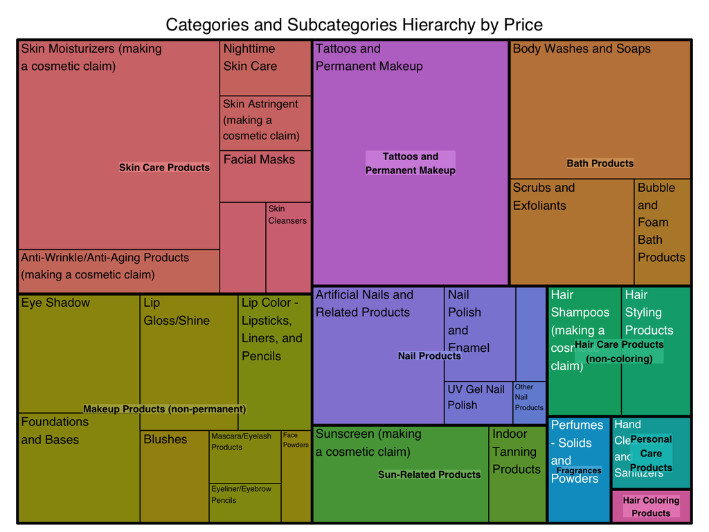

# Division of Chemical Names

- Tree Map of Chemicals by their amount in each product category
- Nail Products have high amount of Titanium dioxide
- Fragnances catergoy seems to have the least amount of Titanium Oxide

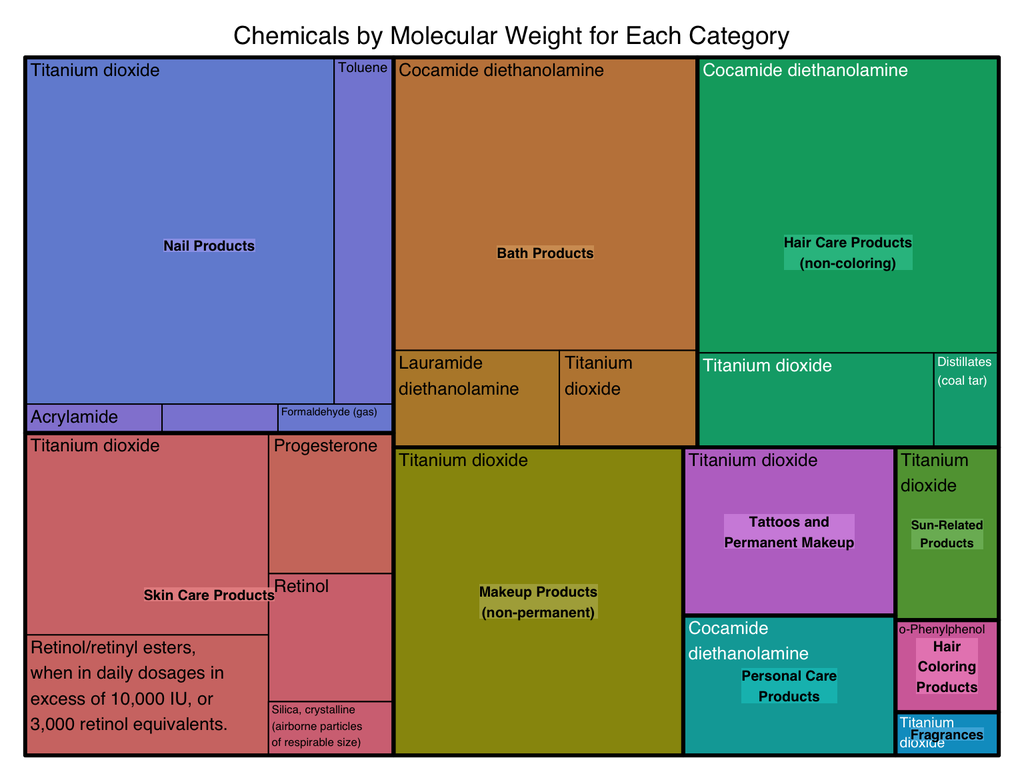

# Chemical Levels by Molecular Weight

- Column Chart of Products Status by Chemical Quantity (out of 100 products)
- Most Products falls under Safe Status based on the Chemical Quantity of 0 to 80 g/mol
- We do have Toxic products present among 100 products ranging toxicity level from 451 to 600 g/mol

```
##
## Alarming     Safe    Toxic   Unsafe
##        3       82        8        6
```

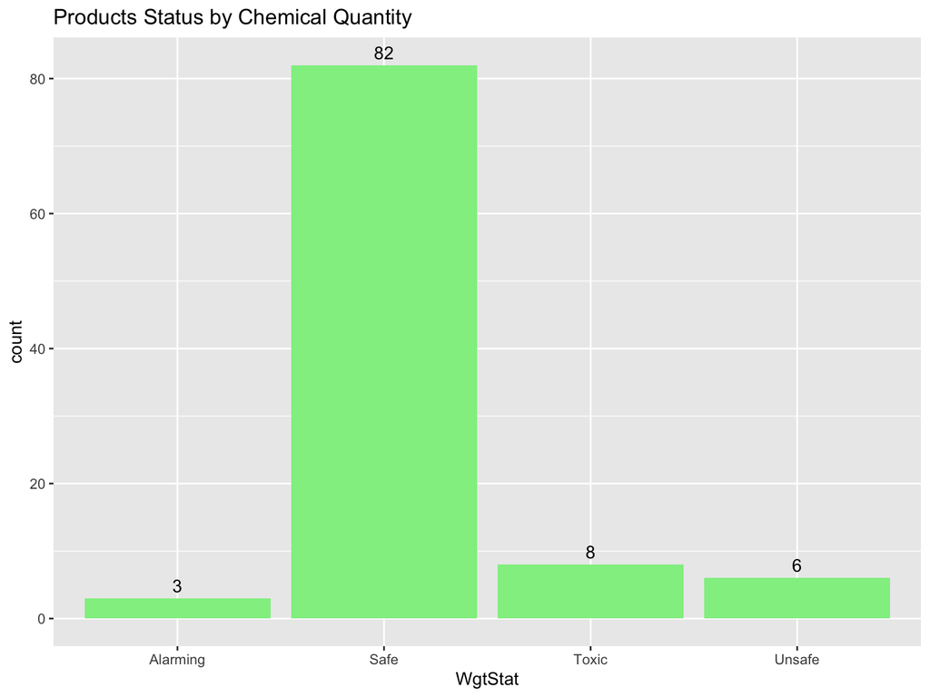

# Cost Levels by Price

- Column Chart of Price Status by Products (out of 100 products)
- Most of the Cosmetics Products are affordable

```
##
##     Average       Cheap       Pricy Very Costly
##          30          38          26           5
```

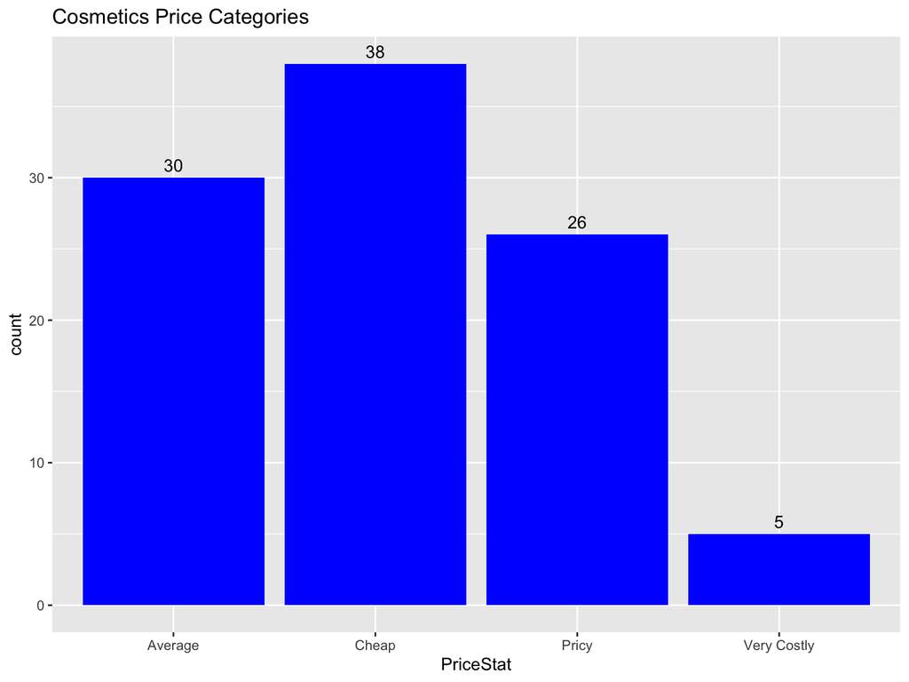

# Weight Staus vs Price Status

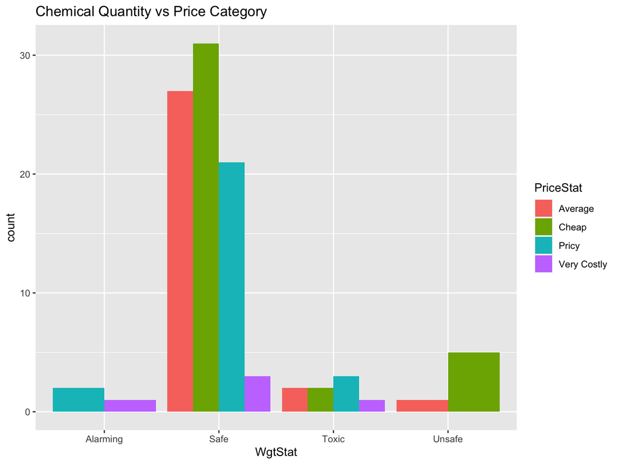

# Popular Categories

- Donut Chart of Cosmetics Categories
- Nail Products are the most popular category

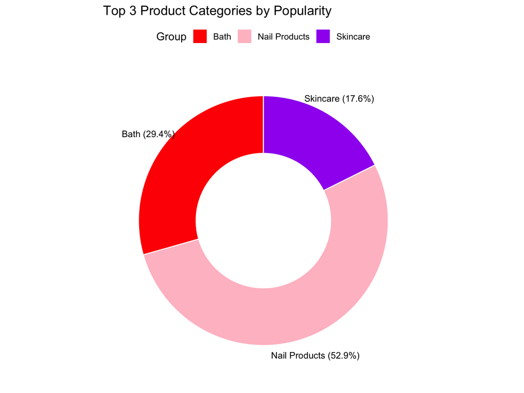

# Common Chemicals

- Pie-Chart on commonly used Chemicals in Cosmetics Products
- Titanium Dioxide is populary used chemical

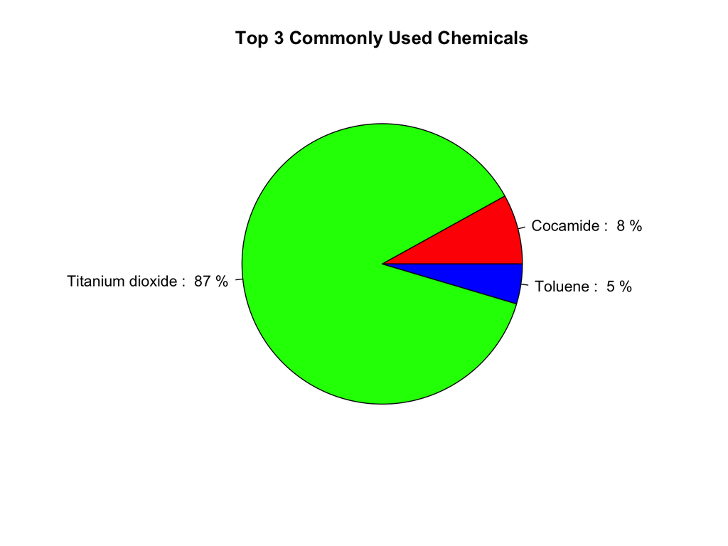